# Constitution

A Drama, initially written sometime around late 2017

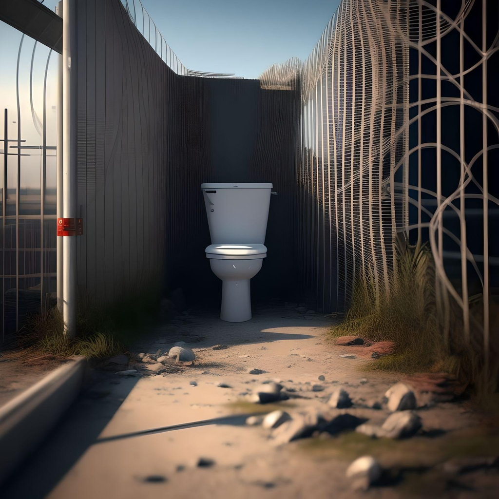

[In a noisy open-bay prison dormitory, one tall, middle-aged inmate (Kevin) excitedly approaches another inmate (James) who is reclining on the bottom rack of a double bunk. James, a slightly younger and shorter sort, places his book upon his chest and listens]

Kevin: Hey, James?

James: What’s up Kevin?

Kevin: The Florida Channel is about to broadcast yesterday’s hearing on juvenile life sentences, if you want to come and watch it.

James: Maybe, I’ve been kind of following that, what are they talking about now?

Kevin: This is the hearing that will determine whether or not the last decision will be retroactive.

James: And the last decision was… that it is unconstitutional to sentence a juvenile to a life sentence without any hope of release?

Kevin: So, that was the U.S. Supreme Court, and that was a few years ago… I guess that was 2010, so four years.

James: That was the Miller Case?

Kevin: No, that was Graham v. Florida. Miller v. Alabama was the case that determined it unconstitutional for juveniles to receive a life sentence without the possibility of parole for homicide cases.

James [confused]: Ok, so…

Kevin: You were, what, six months over eighteen when you caught your case? I’d think you’d be paying closer attention here! I wish I had the luxury of being ignorant of what is going on… These last few years have been a real roller coaster for me.

James: But I didn’t get a life sentence! I got twenty-five years. I’m almost done now… You’re right though. I should be paying closer attention.

Kevin: I don’t know why I keep forgetting you don’t have life. It’s like an automatic assumption with our charge… Murder equals life. You’re a lucky outlier.

James: I know…most of my best friends have life sentences for juvenile cases… I’m going to come and watch it; bring me up to speed real quick.

Kevin: Okay. So, first the U.S. Supreme court ruled that it was illegal to sentence a juvenile to life without the possibility of parole for non-homicide cases. Then, two years later, they decided that applies to homicide cases as well. Now, the Florida Supreme Court is going to decide whether they consider that decision to apply retroactively.

James: What, could it not? They could decide that the decision of the U.S. Supreme Court only applies to those who committed their crime after 2012? So, guys like you – guys that have been in prison for decades – would have to still wear life sentences?

Kevin: Yeah, but we’d be comforted by the knowledge that what happened to us can’t happen to anyone else… that’s the argument anyway! Well, come on, it’s about to start.

James: Ok, just a second. Let me hit the can, and I’ll be right there.

[Kevin leaves, and James sits up to put his shoes on. As Kevin walks away, James’s bunkmate, Steven, approaches. He hesitates before climbing onto the top rack and speaks to James.]

Steven: They just changed the channel. I was right in the middle of a movie, and they changed the fucking channel! I’d be wrong if I floor-modeled that bitch. Inconsiderate fuckers! They want to watch some law bullshit. They should have been worried about the law on the streets, and they wouldn’t be in prison!

James: Well, what they are watching actually is important. It’s the Florida Supreme Court’s decision on whether juvenile life sentences are constitutional or not.

Steven: Juvenile life sentences? Humph. What’s unconstitutional about that?

James: Well, the idea is that giving a juvenile a life sentence is the same as giving him the death penalty, because he’s going to die in prison. The death penalty for juveniles was declared unconstitutional in 2005. Now they are working on the life sentences.

Steven: Fuckers should be in prison for life, the death penalty is too easy for them!

James [stunned]: What?

Steven: Anybody that kills someone deserves to suffer. They should have to do life in prison; the death penalty is letting them off too light. They should do life, and they should send them all to the worst possible prisons – prisons where they get beaten and raped.

James: But… are you serious? People make mistakes! You made a mistake, you’re in prison!

Steven: Not for killing nobody! I just sold some drugs, and it wasn’t no mistake. I knew what I was doing; I wanted some easy money. Those fuckers didn’t make no mistake neither; they knew what they were doing. That’s why it’s called murder – it wasn’t no mistake. They are just sick. They’re sick, and deserve the worst that can happen to them.

James [weakly]: I… the worst that can happen to them? But, the juveniles, they were so young. [gains confidence] They didn’t have the ability to understand the consequences of their actions! Studies have shown that the brain isn’t fully developed until-

Steven [interrupts]: When? 35? That’s a bunch of bullshit. They got kids these days drivin’ around and goin’ to college at 17. If they’s old enough to kill someone then they can deal with the consequences! Aint no mopin’ around feelin’ sorry that some killer is put away forever! That’s what’s best!

James: People can change though…

Steven: Yeah, sure. Those juvenile killers can grow up and become grown-up killers. Once a killer, always a killer. They got diseased minds. Once they get that taste for blood – it’s like a dog – they turn evil; there aint no good in them anymore. You wouldn’t want none of them out there around your family, that’s for sure. James [clearly shaken, hesitates]: You really believe that? I mean, you’re not just talking because you’re mad they changed the channel, but you think that’s true? Really?

Steven[hops up on his rack and considers it for a few moments]: Yeah man.

James: That’s a hell of a thing to say though, “Once a killer, always a killer.” That’s saying that a person that commits murder is not only not like a normal human being anymore, but that they are so un-human that they are not safe for others to be around, ever. Do you really think that’s true?

Steven: I know it is. I known lots of murders since I been locked up, they’re all fucked up. There’s probably even a few of them in here… I don’t trust none of them. That’s why I keep to myself. You never know who you’re talking to around here. Some people are real fucked up.

[James nods his head and walks away. The spotlight follows him to the bathroom, where he quietly sits down on a toilet stool. He places his elbows on his knees, his head in his hands, and begins to weep]